# Prediction model practice exercises

anroco

20/06/2015

## Introduction

The use of devices such as Jawbone Up, Nike FuelBand, and Fitbit it is now possible to collect a large amount of data about personal activity relatively inexpensively. These type of devices are part of the quantified self movement – a group of enthusiasts who take measurements about themselves regularly to improve their health, to find patterns in their behavior, or because they are tech geeks. One thing that people regularly do is quantify how much of a particular activity they do, but they rarely quantify how well they do it. The goal of this project is use data from accelerometers on the belt, forearm, arm, and dumbell of 6 participants. They were asked to perform barbell lifts correctly and incorrectly in 5 different ways.

More information is available this [website](http://groupware.les.inf.puc-rio.br/har) (see the section on the Weight Lifting Exercise Dataset).

## Data Preparation

Libraries needed to be used in the project.

```r
library(lattice)
library(ggplot2)
library(caret)
library(randomForest)
library(rattle)
library(rpart)
```

### Download and load data sets

In this step the data are downloaded and then they are load it into R.

```r
train_url_file <- "https://d396qusza40orc.cloudfront.net/predmachlearn/pml-training.csv"
test_url_file <- "https://d396qusza40orc.cloudfront.net/predmachlearn/pml-testing.csv"
train_name_file <- "pml-training.csv"
test_name_file <- "pml-testing.csv"

#download files (if necessary)
if (!file.exists(train_name_file)) {
  download.file(train_url_file, train_name_file, method="curl")
}
if (!file.exists(test_name_file)) {
  download.file(test_url_file, test_name_file, method="curl")
}

#load files in R
train_raw_data <- read.csv(train_name_file)
test_raw_data <- read.csv(test_name_file)
dim(train_raw_data)
```

```
## [1] 19622   160
```

```r
dim(test_raw_data)
```

```
## [1]  20 160
```

As we see the training dataset has 19622 rows and 160 columns, on the other hand, the test dataset are 20 rows and 160 columns.

### Cleaning data

In this step is done cleaning data by removing the columns that consist of NA values.

```r
#remove the columns that only contain NA values.
train_data <- train_raw_data[, colSums(is.na(train_raw_data)) == 0]
test_data <- test_raw_data[, colSums(is.na(test_raw_data)) == 0]

#remove the raw data sets
rm(train_raw_data)
rm(test_raw_data)

#validate the complete cases
sum(complete.cases(train_data))
```

```
## [1] 19622
```

```r
sum(complete.cases(test_data))
```

```
## [1] 20
```

As we see the training dataset has 19622 complete records, like the test dataset have 20 complete records.

The variables that do not have relevant information on obtaining the model they are removed.

```r
#copy the classe variable
classe_var <- train_data$classe

#remove the columns that are not necessary
train_data <- train_data[, !grepl("^X|timestamp|window", names(train_data))]
test_data <- test_data[, !grepl("^X|timestamp|window", names(test_data))]

#remove the columns that are not numeric.
train_data <- train_data[, sapply(train_data, is.numeric)]
test_data <- test_data[, sapply(test_data, is.numeric)]
train_data$classe <- classe_var

str(train_data)
```

```
## 'data.frame':    19622 obs. of  53 variables:
##  $ roll_belt           : num  1.41 1.41 1.42 1.48 1.48 1.45 1.42 1.42 1.43 1.45 ...
##  $ pitch_belt          : num  8.07 8.07 8.07 8.05 8.07 8.06 8.09 8.13 8.16 8.17 ...
##  $ yaw_belt            : num  -94.4 -94.4 -94.4 -94.4 -94.4 -94.4 -94.4 -94.4 -94.4 -94.4 ...
##  $ total_accel_belt    : int  3 3 3 3 3 3 3 3 3 3 ...
##  $ gyros_belt_x        : num  0 0.02 0 0.02 0.02 0.02 0.02 0.02 0.02 0.03 ...
##  $ gyros_belt_y        : num  0 0 0 0 0.02 0 0 0 0 0 ...
##  $ gyros_belt_z        : num  -0.02 -0.02 -0.02 -0.03 -0.02 -0.02 -0.02 -0.02 -0.02 0 ...
##  $ accel_belt_x        : int  -21 -22 -20 -22 -21 -21 -22 -22 -20 -21 ...
##  $ accel_belt_y        : int  4 4 5 3 2 4 3 4 2 4 ...
##  $ accel_belt_z        : int  22 22 23 21 24 21 21 21 24 22 ...
##  $ magnet_belt_x       : int  -3 -7 -2 -6 -6 0 -4 -2 1 -3 ...
##  $ magnet_belt_y       : int  599 608 600 604 600 603 599 603 602 609 ...
##  $ magnet_belt_z       : int  -313 -311 -305 -310 -302 -312 -311 -313 -312 -308 ...
##  $ roll_arm            : num  -128 -128 -128 -128 -128 -128 -128 -128 -128 -128 ...
```

[output cut: 39 more lines]

```r
dim(train_data)
```

```
## [1] 19622    53
```

```r
str(test_data)
```

```
## 'data.frame':    20 obs. of  53 variables:
##  $ roll_belt           : num  123 1.02 0.87 125 1.35 -5.92 1.2 0.43 0.93 114 ...
##  $ pitch_belt          : num  27 4.87 1.82 -41.6 3.33 1.59 4.44 4.15 6.72 22.4 ...
##  $ yaw_belt            : num  -4.75 -88.9 -88.5 162 -88.6 -87.7 -87.3 -88.5 -93.7 -13.1 ...
##  $ total_accel_belt    : int  20 4 5 17 3 4 4 4 4 18 ...
##  $ gyros_belt_x        : num  -0.5 -0.06 0.05 0.11 0.03 0.1 -0.06 -0.18 0.1 0.14 ...
##  $ gyros_belt_y        : num  -0.02 -0.02 0.02 0.11 0.02 0.05 0 -0.02 0 0.11 ...
##  $ gyros_belt_z        : num  -0.46 -0.07 0.03 -0.16 0 -0.13 0 -0.03 -0.02 -0.16 ...
##  $ accel_belt_x        : int  -38 -13 1 46 -8 -11 -14 -10 -15 -25 ...
##  $ accel_belt_y        : int  69 11 -1 45 4 -16 2 -2 1 63 ...
##  $ accel_belt_z        : int  -179 39 49 -156 27 38 35 42 32 -158 ...
##  $ magnet_belt_x       : int  -13 43 29 169 33 31 50 39 -6 10 ...
##  $ magnet_belt_y       : int  581 636 631 608 566 638 622 635 600 601 ...
##  $ magnet_belt_z       : int  -382 -309 -312 -304 -418 -291 -315 -305 -302 -330 ...
##  $ roll_arm            : num  40.7 0 0 -109 76.1 0 0 0 -137 -82.4 ...
```

[output cut: 39 more lines]

```r
dim(test_data)
```

```
## [1] 20 53
```

Now, the cleaned training data set contains 19622 observations and 53 variables, while the testing data set contains 20 observations and 53 variables. The “classe” variable is still in the cleaned training set.

## Data Modeling

### Cross validation set

The training set is divided in two parts, the first is a training set with 70% of the data which is used to train the model and the other 30% testing is a validation set used to assess model performance.

```r
inTrain = createDataPartition(train_data$classe, p = 0.7, list=FALSE)
training = train_data[inTrain,]
testing = train_data[-inTrain,]
```

### Training

For this project used the algorithm random forest to define the predictive model because it is one of the learning algorithms more accurate than is available, it can also handle hundreds of input variables, as well as automatically select the most important without excluding any, between other advantages, on the other hand, we will use 5-fold cross validation when applying the algorithm.

```r
set.seed(1234)
modelFit <- train(classe ~ ., data = training, method="rf", trControl=trainControl(method='cv', 5), ntree=250, allowParallel=TRUE)
modelFit
```

```
## Random Forest
##
## 13737 samples
##    52 predictors
##     5 classes: 'A', 'B', 'C', 'D', 'E'
##
## No pre-processing
## Resampling: Cross-Validated (5 fold)
##
## Summary of sample sizes: 10987, 10990, 10990, 10990, 10991
##
## Resampling results across tuning parameters:
##
##   mtry  Accuracy   Kappa      Accuracy SD  Kappa SD
##    2    0.9903912  0.9878441  0.001165940  0.001474133
##   27    0.9897357  0.9870143  0.001347783  0.001704972
##   52    0.9819458  0.9771593  0.003346846  0.004236378
##
## Accuracy was used to select the optimal model using  the largest value.
## The final value used for the model was mtry = 2.
```

### Prediction

In this step we estimate the performance of the model on the validation data set, allows forecasting the accuracy and overall out-of-sample error, which indicate how well the model will perform with other data.

```r
predictions <- predict(modelFit, testing)
cm <- confusionMatrix(testing$classe, predictions)
cm
```

```
## Confusion Matrix and Statistics
##
##           Reference
## Prediction    A    B    C    D    E
##          A 1672    2    0    0    0
##          B    3 1135    1    0    0
##          C    0    3 1023    0    0
##          D    0    0   21  942    1
##          E    0    0    0    1 1081
##
## Overall Statistics
##
##                Accuracy : 0.9946
##                  95% CI : (0.9923, 0.9963)
##     No Information Rate : 0.2846
##     P-Value [Acc > NIR] : < 2.2e-16
##
##                   Kappa : 0.9931
##  Mcnemar's Test P-Value : NA
##
## Statistics by Class:
##
##                      Class: A Class: B Class: C Class: D Class: E
## Sensitivity            0.9982   0.9956   0.9789   0.9989   0.9991
## Specificity            0.9995   0.9992   0.9994   0.9955   0.9998
## Pos Pred Value         0.9988   0.9965   0.9971   0.9772   0.9991
## Neg Pred Value         0.9993   0.9989   0.9955   0.9998   0.9998
## Prevalence             0.2846   0.1937   0.1776   0.1602   0.1839
## Detection Rate         0.2841   0.1929   0.1738   0.1601   0.1837
## Detection Prevalence   0.2845   0.1935   0.1743   0.1638   0.1839
## Balanced Accuracy      0.9989   0.9974   0.9892   0.9972   0.9994
```

```r
#get accuracy of the model
postResample(predictions, testing$classe)
```

```
##  Accuracy     Kappa
## 0.9945624 0.9931217
```

```r
#get estimated out-of-sample error of the model
1 - as.numeric(cm$overall[1])
```

```
## [1] 0.005437553
```

So, the estimated accuracy of the model is 99.45% and the estimated out-of-sample error is 0.54%. In the following chart we can see the decision tree model output.

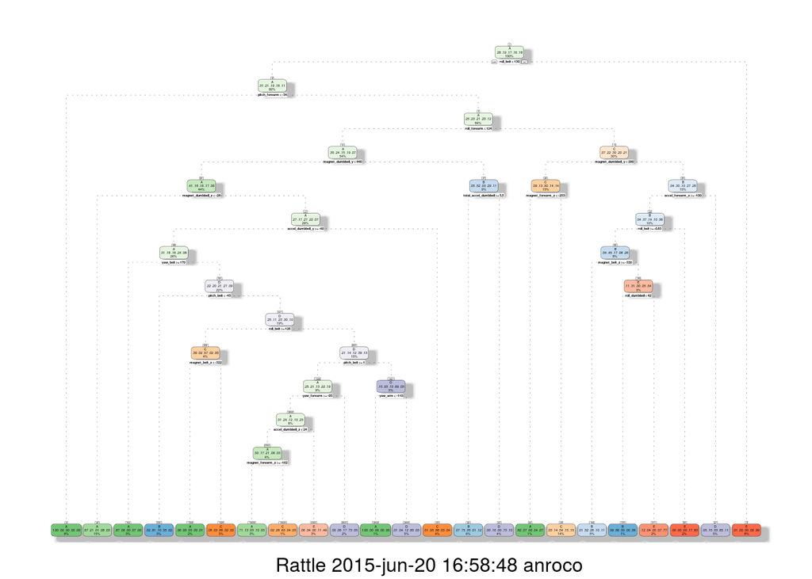

```r
#decision tree visualization
treeModel <- rpart(classe ~ ., data=training, method="class")
fancyRpartPlot(treeModel)
```

## Result of predicting for test dataset

Now, the model is applied to the test data to produce the results.

```r
predict(modelFit, test_data[, -length(names(test_data))])
```

```
##  [1] B A B A A E D B A A B C B A E E A B B B
## Levels: A B C D E
```